# Practical Machine Learning Project Assignment

Richa Agrawal

December 15, 2017

## Practical Machine Learning Project Assignment

This document is the Final Project for the MOOC âPractical Machine Learningâ" from Johns Hopkins University. Assignement Instructions

(Background, Data and What you should submit sections are copied from courseâs assignement page)

### Background

Using devices such as Jawbone Up, Nike FuelBand, and Fitbit it is now possible to collect a large amount of data about personal activity relatively inexpensively. These type of devices are part of the quantified self movement - a group of enthusiasts who take measurements about themselves regularly to improve their health, to find patterns in their behavior, or because they are tech geeks. One thing that people regularly do is quantify how much of a particular activity they do, but they rarely quantify how well they do it. In this project, your goal will be to use data from accelerometers on the belt, forearm, arm, and dumbell of 6 participants. They were asked to perform barbell lifts correctly and incorrectly in 5 different ways. More information is available from the website here: http://groupware.les.inf.puc-rio.br/har (see the section on the Weight Lifting Exercise Dataset).

### Data

The training data for this project are available here: [https://d396qusza40orc.cloudfront.net/predmachlearn/pml-training.csv]

The test data are available here: [https://d396qusza40orc.cloudfront.net/predmachlearn/pml-testing.csv]

The data for this project come from this source: [http://groupware.les.inf.puc-rio.br/har]. If you use the document you create for this class for any purpose please cite them as they have been very generous in allowing their data to be used for this kind of assignment.

### What you should submit

The goal of your project is to predict the manner in which they did the exercise. This is the “classe” variable in the training set. You may use any of the other variables to predict with. You should create a report describing how you built your model, how you used cross validation, what you think the expected out of sample error is, and why you made the choices you did. You will also use your prediction model to predict 20 different test cases.

Your submission should consist of a link to a Github repo with your R markdown and compiled HTML file describing your analysis. Please constrain the text of the writeup to < 2000 words and the number of figures to be less than 5. It will make it easier for the graders if you submit a repo with a gh-pages branch so the HTML page can be viewed online (and you always want to make it easy on graders :-). You should also apply your machine learning algorithm to the 20 test cases available in the test data above. Please submit your predictions in appropriate format to the programming assignment for automated grading. See the programming assignment for additional details. Preliminary Work

### Reproduceability

An overall pseudo-random number generator seed was set at 1234 for all code. In order to reproduce the results below, the same seed should be used. Different packages were downloaded and installed, such as caret and randomForest. These should also be installed in order to reproduce the results below (please see code below for ways and syntax to do so).

### Model Selection

The outcome variable for the model is “classe” variable which is a factor variable and has 5 levels:

- Exactly according to the specification (Class A)
- Throwing the elbows to the front (Class B)
- Lifting the dumbbell only halfway (Class C)
- Lowering the dumbbell only halfway (Class D)
- Throwing the hips to the front (Class E)

Three models shall be tested using Decision Tree, Random Forest and KNN algorithms. Algorithm with the highest accuracy shall be tested against the actual test data set of 20 test cases.

### Cross-validation

Cross-validation will be performed by subsampling the training data set randomly without replacement into 2 subsamples: subTraining data (75% of the original Training data set) and subTesting data (25%). Our models will be fitted on the subTraining data set, and tested on the subTesting data. Once the most accurate model is choosen, it will be tested on the original Testing data set.

### Out-of-sample error

The expected out-of-sample error will correspond to : 1-accuracy in the cross-validation data. Accuracy is the proportion of correctly classified observation over the total number of observations in the subTesting data set. Expected accuracy is the accuracy in the out-of-sample data set (i.e. original testing data set). Thus, the expected value of the out-of-sample error will correspond to the expected number of missclassified observations/total observations in the Test data set.

## Code and Results

### Loading Packages, Libraries and setting Seed

```r
#install.packages("caret")
#install.packages("caTools")
#install.packages("randomForest")
#install.packages("rpart")
#install.packages("rpart.plot")

library(caret)
library(caTools)
library(randomForest)
library(rpart)
library(rpart.plot)
library(class)

set.seed(1234)
```

### Loading data sets, cleaning and splitting them

```r
download.file(url="https://d396qusza40orc.cloudfront.net/predmachlearn/pml-training.csv", destfile="pml-training.csv")

download.file(url="https://d396qusza40orc.cloudfront.net/predmachlearn/pml-testing.csv", destfile="pml-testng.csv")

pml.training<-read.csv("pml-training.csv",na.strings = c("NA","#DIV/0!", ""))
pml.testing<-read.csv("pml-testing.csv", na.strings = c("NA","#DIV/0!", ""))

#Check the dimensions of training and test data sets
dim(pml.training)
```

```
## [1] 19622   160
```

```r
dim(pml.testing)
```

```
## [1]  20 160
```

```r
#remove the columns which have NAs
pml.training<-pml.training[,colSums(is.na(pml.training))==0]
pml.testing<-pml.testing[,colSums(is.na(pml.testing))==0]

#remove columns 1:7 which are irrelevant
pml.training<-pml.training[,-c(1:7)]
pml.testing<-pml.testing[,-c(1:7)]

#Check the dimensions of training and test data sets post processing
dim(pml.training)
```

```
## [1] 19622    53
```

```r
dim(pml.testing)
```

```
## [1] 20 53
```

```r
#split the training data into subTraining and SubTesting data sets (0.75:0.25)
split<-sample.split(Y=pml.training,SplitRatio=3/4)
subTraining<-subset(pml.training,split==TRUE)
subTesting<-subset(pml.training,split==FALSE)

#check the dimensions of subtraining and subtesting data sets
dim(subTraining)
```

```
## [1] 14439    53
```

```r
dim(subTesting)
```

```
## [1] 5183   53
```

## Including Plots

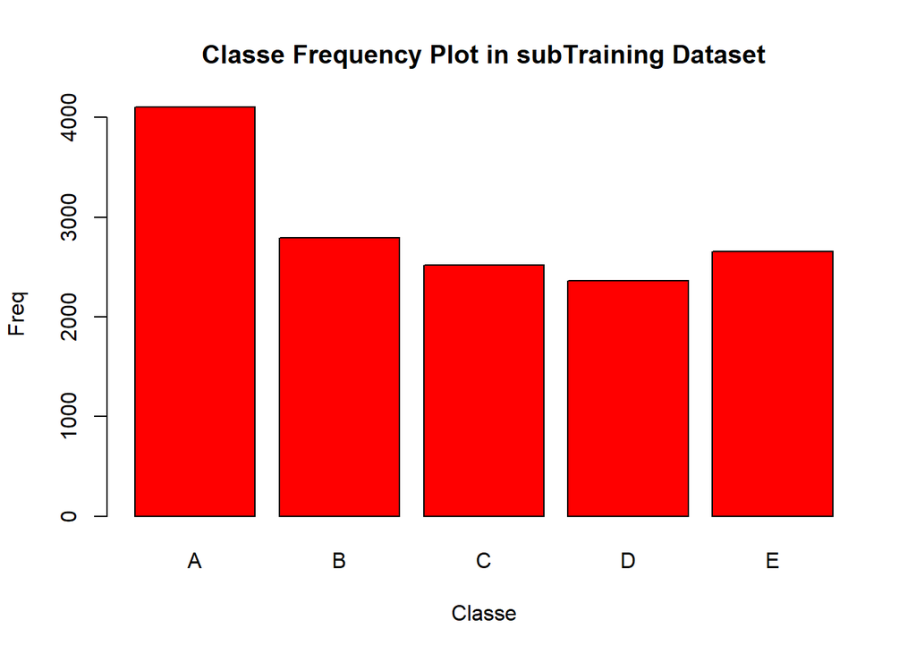

### First prediction model: Decision Tree

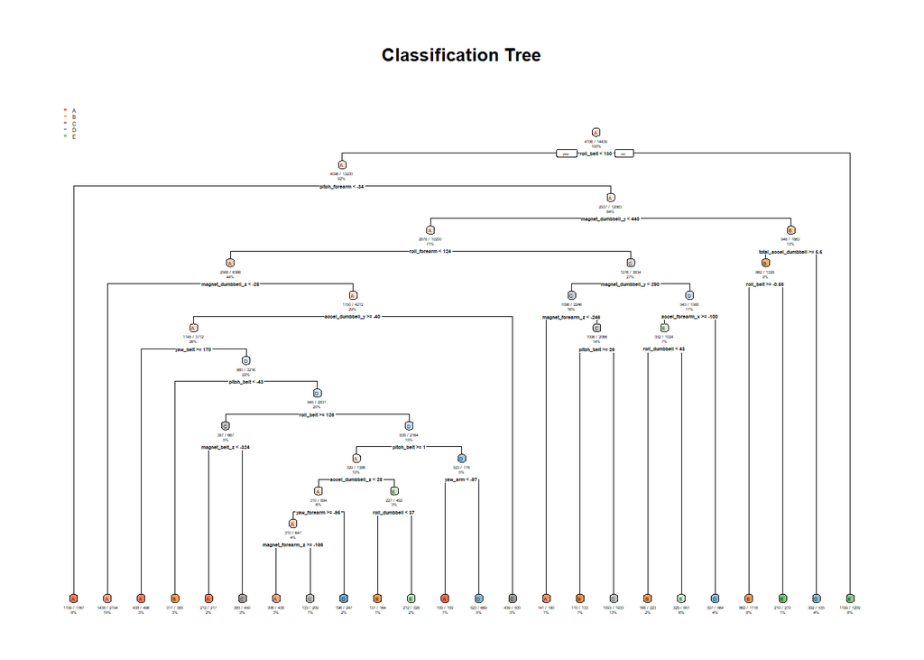

```r
model1<-rpart(classe~.,data=subTraining, method = "class")
prediction1<-predict(model1,subTesting,type="class")

rpart.plot(model1, main="Classification Tree", extra=102, under=TRUE, faclen=0)
```

```r
confusionMatrix(prediction1, subTesting$classe)
```

```
## Confusion Matrix and Statistics
##
##           Reference
## Prediction    A    B    C    D    E
##          A 1350  202   16   84   34
##          B   39  561   50   28   60
##          C   40   96  729  129  117
##          D   20   68   54  538   53
##          E   25   75   55   71  689
##
## Overall Statistics
##
##                Accuracy : 0.7461
##                  95% CI : (0.734, 0.7579)
##     No Information Rate : 0.2844
##     P-Value [Acc > NIR] : < 2.2e-16
##
##                   Kappa : 0.6773
##  Mcnemar's Test P-Value : < 2.2e-16
##
## Statistics by Class:
##
##                      Class: A Class: B Class: C Class: D Class: E
## Sensitivity            0.9159   0.5599   0.8064   0.6329   0.7230
## Specificity            0.9094   0.9577   0.9107   0.9550   0.9466
## Pos Pred Value         0.8007   0.7602   0.6562   0.7340   0.7530
## Neg Pred Value         0.9645   0.9008   0.9570   0.9299   0.9381
## Prevalence             0.2844   0.1933   0.1744   0.1640   0.1839
## Detection Rate         0.2605   0.1082   0.1407   0.1038   0.1329
## Detection Prevalence   0.3253   0.1424   0.2144   0.1414   0.1765
## Balanced Accuracy      0.9126   0.7588   0.8586   0.7940   0.8348
```

```r
confusionMatrix(prediction1, subTesting$classe)$overall['Accuracy']
```

```
## Accuracy
## 0.746093
```

### Second prediction model: Random Forest

```r
model2<-randomForest(classe~., data=subTraining, method="class")

prediction2<-predict(model2, subTesting, type="class")

confusionMatrix(prediction2, subTesting$classe)
```

```
## Confusion Matrix and Statistics
##
##           Reference
## Prediction    A    B    C    D    E
##          A 1473    1    0    0    0
##          B    1 1001    4    0    0
##          C    0    0  900   10    0
##          D    0    0    0  839    4
##          E    0    0    0    1  949
##
## Overall Statistics
##
##                Accuracy : 0.9959
##                  95% CI : (0.9938, 0.9975)
##     No Information Rate : 0.2844
##     P-Value [Acc > NIR] : < 2.2e-16
##
##                   Kappa : 0.9949
##  Mcnemar's Test P-Value : NA
##
## Statistics by Class:
##
##                      Class: A Class: B Class: C Class: D Class: E
## Sensitivity            0.9993   0.9990   0.9956   0.9871   0.9958
## Specificity            0.9997   0.9988   0.9977   0.9991   0.9998
## Pos Pred Value         0.9993   0.9950   0.9890   0.9953   0.9989
## Neg Pred Value         0.9997   0.9998   0.9991   0.9975   0.9991
## Prevalence             0.2844   0.1933   0.1744   0.1640   0.1839
## Detection Rate         0.2842   0.1931   0.1736   0.1619   0.1831
## Detection Prevalence   0.2844   0.1941   0.1756   0.1626   0.1833
## Balanced Accuracy      0.9995   0.9989   0.9966   0.9931   0.9978
```

```r
confusionMatrix(prediction2, subTesting$classe)$overall['Accuracy']
```

```
##  Accuracy
## 0.9959483
```

### Third prediction model: K-Nearest Neighbour

```r
model3<-knn(train=subTraining[,-53],test=subTesting[,-53], cl=subTraining$classe, k=5)

confusionMatrix(model3, subTesting$classe)
```

```
## Confusion Matrix and Statistics
##
##           Reference
## Prediction    A    B    C    D    E
##          A 1432   39    5   10   10
##          B   10  892   36    4   21
##          C   11   27  835   58   14
##          D   17   26   19  770   19
##          E    4   18    9    8  889
##
## Overall Statistics
##
##                Accuracy : 0.9296
##                  95% CI : (0.9223, 0.9364)
##     No Information Rate : 0.2844
##     P-Value [Acc > NIR] : < 2.2e-16
##
##                   Kappa : 0.9109
##  Mcnemar's Test P-Value : 1.855e-10
##
## Statistics by Class:
##
##                      Class: A Class: B Class: C Class: D Class: E
## Sensitivity            0.9715   0.8902   0.9237   0.9059   0.9328
## Specificity            0.9827   0.9830   0.9743   0.9813   0.9908
## Pos Pred Value         0.9572   0.9263   0.8836   0.9048   0.9580
## Neg Pred Value         0.9886   0.9739   0.9837   0.9815   0.9850
## Prevalence             0.2844   0.1933   0.1744   0.1640   0.1839
## Detection Rate         0.2763   0.1721   0.1611   0.1486   0.1715
## Detection Prevalence   0.2886   0.1858   0.1823   0.1642   0.1790
## Balanced Accuracy      0.9771   0.9366   0.9490   0.9436   0.9618
```

```r
confusionMatrix(model3, subTesting$classe)$overall['Accuracy']
```

```
##  Accuracy
## 0.9295775
```

## Comparision of models and Decision

```r
Algos<-c("Decision Tree","Random Forest","KNN")
Accuracy<-c(confusionMatrix(prediction1, subTesting$classe)$overall['Accuracy'],
            confusionMatrix(prediction2, subTesting$classe)$overall['Accuracy'],
            confusionMatrix(model3, subTesting$classe)$overall['Accuracy'])
rbind(Algos,Accuracy)
```

```
##          Accuracy            Accuracy            Accuracy
## Algos    "Decision Tree"     "Random Forest"     "KNN"
## Accuracy "0.746092996334169" "0.995948292494694" "0.929577464788732"
```

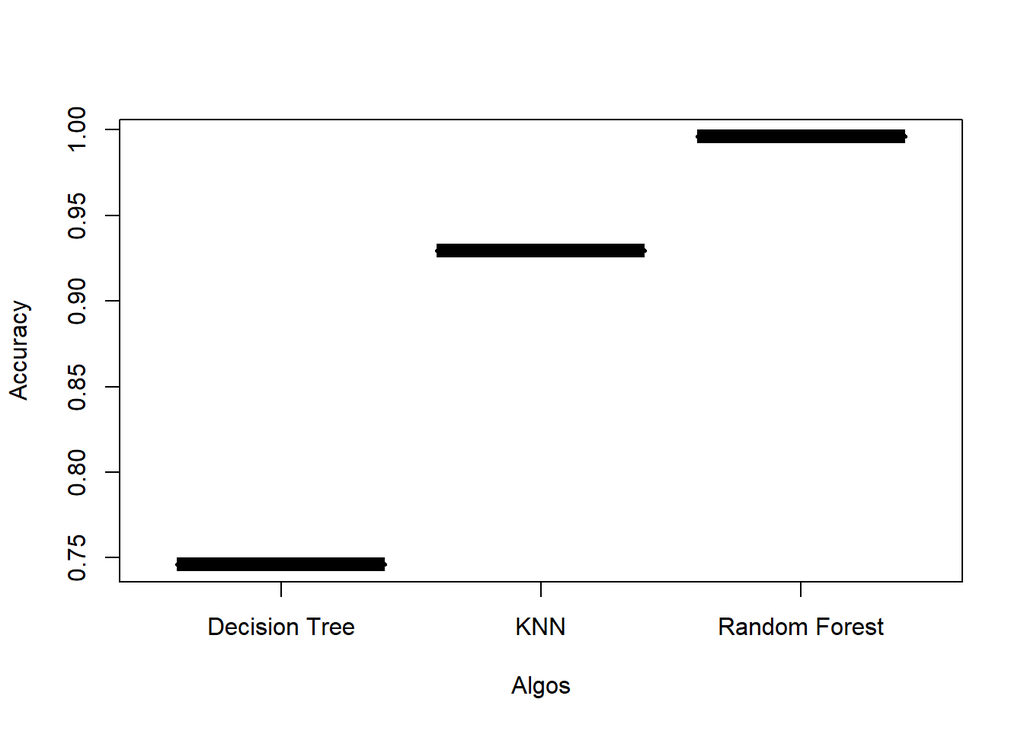

```r
model.results<-data.frame(Algos=Algos,Accuracy=Accuracy)
plot(model.results,lwd=3)
```

As expected, Random Forest algorithm performed better than Decision Tree and KNN. Accuracy for Random Forest model was 0.9959 (95% CI : (0.9938, 0.9975)) compared to 0.7461 (95% CI : (0.734, 0.7579)) for Decision Tree model and 0.9296 (95% CI : (0.9223, 0.9364) for KNN.

The random Forest model is choosen. The accuracy of the model is 0.995.

The expected out-of-sample error is estimated at 0.005, or 0.5%. The expected out-of-sample error is calculated as 1 - accuracy for predictions made against the cross-validation set. Our Test data set comprises 20 cases. With an accuracy above 99% on our cross-validation data, we can expect that very few, or none, of the test samples will be missclassified.

## Final Predictions

```r
Predictions<-predict(model2, pml.testing, type="class")
Predictions
```

```
##  1  2  3  4  5  6  7  8  9 10 11 12 13 14 15 16 17 18 19 20
##  B  A  B  A  A  E  D  B  A  A  B  C  B  A  E  E  A  B  B  B
## Levels: A B C D E
```